# Análisis exploratorio SUDMEX CONN

Author

Edgar

Published

October 4, 2022

Para disminuir la carga visual de este notebook alguns de las funciones se encuentran en el archivo `funciones.R` que se carga en un chunk especifico que no se incluye en la salida html para evitar output inesecesario.

Incluir en el chunck la opción `#| include:false` permite ejecutar pero no incluir el código

## Preparar variables

Definimos las variables para la extracción de los datos de la pagina de Zenodo. Y de paso generamos el directorio donde podremos guardar los archivos.

**Note**

Al usar `here()` dejamos usamos la raíz del repositorio para guardar los archivos.

```r
sitio <- c('https://zenodo.org/')
pagina <- c('record/5123330')
dir.create(here('descargas'), showWarnings=FALSE)
```

## Links y rutas de descaragas

A partir de las rutas de archivos en el sitio web podemos generar los links de descargas y las rutas para salvar los archivos, todo recolectado en un dataframe.

```r
df_fuentes <- ObtenerFuentesArchivos(
    sitio = sitio,
    pagina = pagina,
    directorio_descargas = here("descargas")
)
df_fuentes
```

| url | destino |
| --- | --- |
| https://zenodo.org//record/6301040/files/Connectome_demographics%20050219.xlsx?download=1 | /home/nekrum/proyectos/datavix_lanirem/descargas/Connectome_demographics_20050219.xlsx |
| https://zenodo.org//record/6301040/files/Connectome_DERS%20050219.xlsx?download=1 | /home/nekrum/proyectos/datavix_lanirem/descargas/Connectome_DERS_20050219.xlsx |
| https://zenodo.org//record/6301040/files/Connectome_DES%20050219.xlsx?download=1 | /home/nekrum/proyectos/datavix_lanirem/descargas/Connectome_DES_20050219.xlsx |
| https://zenodo.org//record/6301040/files/Connectome_DIB%20050219.xlsx?download=1 | /home/nekrum/proyectos/datavix_lanirem/descargas/Connectome_DIB_20050219.xlsx |
| https://zenodo.org//record/6301040/files/Connectome_DSS4%20050219.xlsx?download=1 | /home/nekrum/proyectos/datavix_lanirem/descargas/Connectome_DSS4_20050219.xlsx |
| https://zenodo.org//record/6301040/files/Connectome_instantview%20050219.xlsx?download=1 | /home/nekrum/proyectos/datavix_lanirem/descargas/Connectome_instantview_20050219.xlsx |
| https://zenodo.org//record/6301040/files/Connectome_MINI%20050219.xlsx?download=1 | /home/nekrum/proyectos/datavix_lanirem/descargas/Connectome_MINI_20050219.xlsx |
| https://zenodo.org//record/6301040/files/Connectome_SCID%20050219.xlsx?download=1 | /home/nekrum/proyectos/datavix_lanirem/descargas/Connectome_SCID_20050219.xlsx |
| https://zenodo.org//record/6301040/files/Connectome_SCL90%20%20050219.xlsx?download=1 | /home/nekrum/proyectos/datavix_lanirem/descargas/Connectome_SCL90_20_20050219.xlsx |
| https://zenodo.org//record/6301040/files/Connectome_WHODAS%20050219.xlsx?download=1 | /home/nekrum/proyectos/datavix_lanirem/descargas/Connectome_WHODAS_20050219.xlsx |

[output cut: 1 more lines]

## Descarga de archivos

Podemos iterar sobre cada renglón de dataframe para descargar todos los archivos de la página.

```r
df_demographics <- df_fuentes %>%
    filter(grepl("demographics", url))

DescargaArchivos(df_demographics)
```

Esta función descargara cada archivo que se encuentra en la columna de **url()**. Puede filtrarse este dataframe para solo descargar los archivos necesarios, de lo contrario se bajaran todos los archivos dentro de la página.

**Warning**

Cada vez que se ejecuta este script se descargan los archivos.

## Leer datos demográficos

Podemos rehusar el dataframe para leer el excel con los datos demográficos

```r
library(readxl)

demo_data <- read_excel(df_demographics$destino, sheet = "Demographics")
head(demo_data)
```

| rid | group | demo | sex | age | educ | occup | income | civil_st | child | child_num | bro_num | place_bro | prof_mental | years_mental | hosp_subst | support_ever | support_years | work_thirtydays | work_threeyears | energy_freq | energy_recent | energy_cans | laterality | ed_score | amai | amai_score | notes |
| --- | --- | --- | --- | --- | --- | --- | --- | --- | --- | --- | --- | --- | --- | --- | --- | --- | --- | --- | --- | --- | --- | --- | --- | --- | --- | --- | --- |
| 1 | 1 | 1 | 1 | 41 | 7 | 7 | 20000 | 1 | 0 | 0 | NA | 3 | 0 | 0 | 0 | 0 | 0 | 1 | 1 | 0 | 0 | 0 | 1 | 87.5 | 7 | 222 | NA |
| 2 | 2 | 1 | 1 | 23 | 5 | 3 | 7100 | 6 | 0 | 0 | 4 | 1 | 0 | 0 | 0 | 0 | 0 | 1 | 4 | 0 | 0 | 0 | 1 | 87.5 | 3 | 104 | NA |
| 3 | 2 | 1 | 1 | 27 | 5 | 4 | 12000 | 6 | 0 | 0 | NA | 2 | 3 | 2 | 0 | 0 | 0 | 4 | 1 | 0 | 0 | 0 | 2 | -87.5 | 7 | 219 | NA |
| 4 | 1 | 1 | 1 | 27 | 5 | 7 | 10000 | 6 | 0 | 0 | 2 | 1 | 0 | 0 | 0 | 0 | 0 | 2 | 2 | 0 | 0 | 0 | 1 | 100 | 4 | 110 | NA |
| 5 | 1 | 1 | 1 | 23 | 5 | 7 | 6000 | 6 | 0 | 0 | 3 | 3 | 0 | 0 | 0 | 0 | 0 | 2 | 4 | 0 | 0 | 0 | 1 | 100 | 3 | 94 | NA |
| 6 | 2 | 1 | 1 | 27 | 4 | 4 | 6000 | 2 | 1 | 2 | 3 | 3 | 3 | 0 | 0 | 0 | 0 | NA | NA | 1 | 0 | 0 | 3 | 0 | 6 | 139 | NA |

Leemos la definición de las variables de la segunda hoja dentro del archivo.

```r
diccionario <- read_excel(
    df_demographics$destino,
    sheet = "Connectome_demographics",
    range=cell_cols(c("A","D"))
)
diccionario
```

| VARIABLE | id | table_name | DEFINITION |
| --- | --- | --- | --- |
| rid | general information | Sociodemographic_data | Rooster ID |
| group | general information | Sociodemographic_data | assignment group |
| demo | general information | Sociodemographic_data | demographic data form |
| sex | questions | Sociodemographic_data | sex |
| age | questions | Sociodemographic_data | years of age |
| educ | questions | Sociodemographic_data | education |
| occup | questions | Sociodemographic_data | occupation |
| income | questions | Sociodemographic_data | monthly salary in Mexican pesos |
| civil_st | questions | Sociodemographic_data | civil status |
| child | questions | Sociodemographic_data | children |

[output cut: 17 more lines]

# Exploratory Data Analysis (EDA)

Un paso mas allá de las herramientas clasicas como `str()`, `head()`, `tail()`, `dim()`, `glimpse()`, `View()` y `summary()` estan los paquetes que dan información directa sobre la distribución de los valores o los valores faltantes.

Salvo la librería `glimpse()` de *dplyr* todas estas librerías se incluyen en R base

Para esto podemos usar dos librerías para hacer el análisis exploratorio, seguramente en la comunidad de R habrá mas paquetes disponibles. Pero estos me han resultado útiles.

## Skimr

Esta librería data una información condensada de nuestros datos incluyendo los datos ausentes, tipo de datos e incluso pequeños histogramas de las variables númericas. Su impresion en consola es excelente y su impresion en un reporte como este funciona adecuadamente.

```r
library(skimr)

skim(demo_data)
```

Data summary

| Name | demo_data |
| --- | --- |
| Number of rows | 139 |
| Number of columns | 28 |
| _______________________ |  |
| Column type frequency: |  |
| character | 24 |
| logical | 1 |
| numeric | 3 |
| ________________________ |  |
| Group variables | None |

**Variable type: character**

| skim_variable | n_missing | complete_rate | min | max | empty | n_unique | whitespace |
| --- | --- | --- | --- | --- | --- | --- | --- |
| sex | 0 | 1.00 | 1 | 2 | 0 | 3 | 0 |
| age | 0 | 1.00 | 2 | 2 | 0 | 32 | 0 |
| educ | 0 | 1.00 | 1 | 2 | 0 | 7 | 0 |
| occup | 0 | 1.00 | 1 | 2 | 0 | 11 | 0 |
| income | 0 | 1.00 | 1 | 6 | 0 | 41 | 0 |
| civil_st | 0 | 1.00 | 1 | 2 | 0 | 7 | 0 |
| child | 0 | 1.00 | 1 | 2 | 0 | 3 | 0 |
| child_num | 0 | 1.00 | 1 | 2 | 0 | 6 | 0 |
| bro_num | 0 | 1.00 | 1 | 2 | 0 | 11 | 0 |
| place_bro | 0 | 1.00 | 1 | 2 | 0 | 10 | 0 |
| prof_mental | 1 | 0.99 | 1 | 11 | 0 | 21 | 0 |
| years_mental | 0 | 1.00 | 1 | 4 | 0 | 18 | 0 |
| hosp_subst | 1 | 0.99 | 1 | 4 | 0 | 9 | 0 |
| support_ever | 0 | 1.00 | 1 | 2 | 0 | 4 | 0 |
| support_years | 0 | 1.00 | 1 | 4 | 0 | 13 | 0 |
| work_thirtydays | 0 | 1.00 | 1 | 2 | 0 | 9 | 0 |
| work_threeyears | 0 | 1.00 | 1 | 3 | 0 | 10 | 0 |
| energy_freq | 0 | 1.00 | 1 | 2 | 0 | 4 | 0 |
| energy_recent | 0 | 1.00 | 1 | 2 | 0 | 3 | 0 |
| energy_cans | 0 | 1.00 | 1 | 2 | 0 | 5 | 0 |
| laterality | 0 | 1.00 | 1 | 2 | 0 | 4 | 0 |
| ed_score | 0 | 1.00 | 1 | 5 | 0 | 10 | 0 |
| amai | 0 | 1.00 | 1 | 2 | 0 | 8 | 0 |
| amai_score | 0 | 1.00 | 2 | 3 | 0 | 76 | 0 |

**Variable type: logical**

| skim_variable | n_missing | complete_rate | mean | count |
| --- | --- | --- | --- | --- |
| notes | 139 | 0 | NaN | : |

**Variable type: numeric**

| skim_variable | n_missing | complete_rate | mean | sd | p0 | p25 | p50 | p75 | p100 | hist |
| --- | --- | --- | --- | --- | --- | --- | --- | --- | --- | --- |
| rid | 0 | 1 | 75.27 | 45.56 | 1 | 35.5 | 73 | 114.5 | 160 | ▇▇▆▇▆ |
| group | 0 | 1 | 1.53 | 0.50 | 1 | 1.0 | 2 | 2.0 | 2 | ▇▁▁▁▇ |
| demo | 0 | 1 | 0.81 | 0.40 | 0 | 1.0 | 1 | 1.0 | 1 | ▂▁▁▁▇ |

### Skim agrupado

Ademas soporta reportes agrupados por alguna de las variables involucradas. Sin embargo su uso es simple y puede resultar algo rigido.

```r
demo_data %>% group_by(sex) %>% skim()
```

Data summary

| Name | Piped data |
| --- | --- |
| Number of rows | 139 |
| Number of columns | 28 |
| _______________________ |  |
| Column type frequency: |  |
| character | 23 |
| logical | 1 |
| numeric | 3 |
| ________________________ |  |
| Group variables | sex |

**Variable type: character**

| skim_variable | sex | n_missing | complete_rate | min | max | empty | n_unique | whitespace |
| --- | --- | --- | --- | --- | --- | --- | --- | --- |
| age | 1 | 0 | 1.00 | 2 | 2 | 0 | 29 | 0 |
| age | 2 | 0 | 1.00 | 2 | 2 | 0 | 14 | 0 |
| age | NA | 0 | 1.00 | 2 | 2 | 0 | 1 | 0 |
| educ | 1 | 0 | 1.00 | 1 | 2 | 0 | 7 | 0 |
| educ | 2 | 0 | 1.00 | 1 | 1 | 0 | 5 | 0 |
| educ | NA | 0 | 1.00 | 2 | 2 | 0 | 1 | 0 |
| occup | 1 | 0 | 1.00 | 1 | 2 | 0 | 11 | 0 |
| occup | 2 | 0 | 1.00 | 1 | 2 | 0 | 7 | 0 |
| occup | NA | 0 | 1.00 | 2 | 2 | 0 | 1 | 0 |
| income | 1 | 0 | 1.00 | 1 | 5 | 0 | 35 | 0 |
| income | 2 | 0 | 1.00 | 1 | 6 | 0 | 11 | 0 |
| income | NA | 0 | 1.00 | 2 | 2 | 0 | 1 | 0 |
| civil_st | 1 | 0 | 1.00 | 1 | 2 | 0 | 7 | 0 |
| civil_st | 2 | 0 | 1.00 | 1 | 2 | 0 | 6 | 0 |
| civil_st | NA | 0 | 1.00 | 2 | 2 | 0 | 1 | 0 |
| child | 1 | 0 | 1.00 | 1 | 2 | 0 | 3 | 0 |
| child | 2 | 0 | 1.00 | 1 | 2 | 0 | 3 | 0 |
| child | NA | 0 | 1.00 | 2 | 2 | 0 | 1 | 0 |
| child_num | 1 | 0 | 1.00 | 1 | 2 | 0 | 6 | 0 |
| child_num | 2 | 0 | 1.00 | 1 | 2 | 0 | 6 | 0 |
| child_num | NA | 0 | 1.00 | 2 | 2 | 0 | 1 | 0 |
| bro_num | 1 | 0 | 1.00 | 1 | 2 | 0 | 10 | 0 |
| bro_num | 2 | 0 | 1.00 | 1 | 2 | 0 | 8 | 0 |
| bro_num | NA | 0 | 1.00 | 2 | 2 | 0 | 1 | 0 |
| place_bro | 1 | 0 | 1.00 | 1 | 2 | 0 | 9 | 0 |
| place_bro | 2 | 0 | 1.00 | 1 | 2 | 0 | 7 | 0 |
| place_bro | NA | 0 | 1.00 | 2 | 2 | 0 | 1 | 0 |
| prof_mental | 1 | 1 | 0.99 | 1 | 5 | 0 | 18 | 0 |
| prof_mental | 2 | 0 | 1.00 | 1 | 11 | 0 | 8 | 0 |
| prof_mental | NA | 0 | 1.00 | 2 | 2 | 0 | 1 | 0 |
| years_mental | 1 | 0 | 1.00 | 1 | 4 | 0 | 17 | 0 |
| years_mental | 2 | 0 | 1.00 | 1 | 4 | 0 | 6 | 0 |
| years_mental | NA | 0 | 1.00 | 2 | 2 | 0 | 1 | 0 |
| hosp_subst | 1 | 0 | 1.00 | 1 | 4 | 0 | 8 | 0 |
| hosp_subst | 2 | 1 | 0.95 | 1 | 2 | 0 | 4 | 0 |
| hosp_subst | NA | 0 | 1.00 | 2 | 2 | 0 | 1 | 0 |
| support_ever | 1 | 0 | 1.00 | 1 | 2 | 0 | 4 | 0 |
| support_ever | 2 | 0 | 1.00 | 1 | 2 | 0 | 3 | 0 |
| support_ever | NA | 0 | 1.00 | 2 | 2 | 0 | 1 | 0 |
| support_years | 1 | 0 | 1.00 | 1 | 4 | 0 | 12 | 0 |
| support_years | 2 | 0 | 1.00 | 1 | 4 | 0 | 5 | 0 |
| support_years | NA | 0 | 1.00 | 2 | 2 | 0 | 1 | 0 |
| work_thirtydays | 1 | 0 | 1.00 | 1 | 2 | 0 | 8 | 0 |
| work_thirtydays | 2 | 0 | 1.00 | 1 | 2 | 0 | 7 | 0 |
| work_thirtydays | NA | 0 | 1.00 | 2 | 2 | 0 | 1 | 0 |
| work_threeyears | 1 | 0 | 1.00 | 1 | 2 | 0 | 8 | 0 |
| work_threeyears | 2 | 0 | 1.00 | 1 | 3 | 0 | 8 | 0 |
| work_threeyears | NA | 0 | 1.00 | 2 | 2 | 0 | 1 | 0 |
| energy_freq | 1 | 0 | 1.00 | 1 | 2 | 0 | 4 | 0 |
| energy_freq | 2 | 0 | 1.00 | 1 | 2 | 0 | 4 | 0 |
| energy_freq | NA | 0 | 1.00 | 2 | 2 | 0 | 1 | 0 |
| energy_recent | 1 | 0 | 1.00 | 1 | 2 | 0 | 3 | 0 |
| energy_recent | 2 | 0 | 1.00 | 1 | 2 | 0 | 3 | 0 |
| energy_recent | NA | 0 | 1.00 | 2 | 2 | 0 | 1 | 0 |
| energy_cans | 1 | 0 | 1.00 | 1 | 2 | 0 | 5 | 0 |
| energy_cans | 2 | 0 | 1.00 | 1 | 2 | 0 | 4 | 0 |
| energy_cans | NA | 0 | 1.00 | 2 | 2 | 0 | 1 | 0 |
| laterality | 1 | 0 | 1.00 | 1 | 2 | 0 | 4 | 0 |
| laterality | 2 | 0 | 1.00 | 1 | 1 | 0 | 2 | 0 |
| laterality | NA | 0 | 1.00 | 1 | 1 | 0 | 1 | 0 |
| ed_score | 1 | 0 | 1.00 | 1 | 5 | 0 | 10 | 0 |
| ed_score | 2 | 0 | 1.00 | 2 | 4 | 0 | 3 | 0 |
| ed_score | NA | 0 | 1.00 | 2 | 2 | 0 | 1 | 0 |
| amai | 1 | 0 | 1.00 | 1 | 2 | 0 | 8 | 0 |
| amai | 2 | 0 | 1.00 | 1 | 1 | 0 | 7 | 0 |
| amai | NA | 0 | 1.00 | 2 | 2 | 0 | 1 | 0 |
| amai_score | 1 | 0 | 1.00 | 2 | 3 | 0 | 68 | 0 |
| amai_score | 2 | 0 | 1.00 | 2 | 3 | 0 | 19 | 0 |
| amai_score | NA | 0 | 1.00 | 2 | 2 | 0 | 1 | 0 |

**Variable type: logical**

| skim_variable | sex | n_missing | complete_rate | mean | count |
| --- | --- | --- | --- | --- | --- |
| notes | 1 | 117 | 0 | NaN | : |
| notes | 2 | 20 | 0 | NaN | : |
| notes | NA | 2 | 0 | NaN | : |

**Variable type: numeric**

| skim_variable | sex | n_missing | complete_rate | mean | sd | p0 | p25 | p50 | p75 | p100 | hist |
| --- | --- | --- | --- | --- | --- | --- | --- | --- | --- | --- | --- |
| rid | 1 | 0 | 1 | 70.25 | 45.09 | 1 | 32.00 | 66.0 | 107.00 | 160 | ▇▇▇▅▅ |
| rid | 2 | 0 | 1 | 98.85 | 39.64 | 12 | 80.50 | 110.0 | 124.25 | 154 | ▂▂▂▇▃ |
| rid | NA | 0 | 1 | 133.50 | 0.71 | 133 | 133.25 | 133.5 | 133.75 | 134 | ▇▁▁▁▇ |
| group | 1 | 0 | 1 | 1.56 | 0.50 | 1 | 1.00 | 2.0 | 2.00 | 2 | ▆▁▁▁▇ |
| group | 2 | 0 | 1 | 1.45 | 0.51 | 1 | 1.00 | 1.0 | 2.00 | 2 | ▇▁▁▁▆ |
| group | NA | 0 | 1 | 1.00 | 0.00 | 1 | 1.00 | 1.0 | 1.00 | 1 | ▁▁▇▁▁ |
| demo | 1 | 0 | 1 | 0.81 | 0.39 | 0 | 1.00 | 1.0 | 1.00 | 1 | ▂▁▁▁▇ |
| demo | 2 | 0 | 1 | 0.85 | 0.37 | 0 | 1.00 | 1.0 | 1.00 | 1 | ▂▁▁▁▇ |
| demo | NA | 0 | 1 | 0.00 | 0.00 | 0 | 0.00 | 0.0 | 0.00 | 0 | ▁▁▇▁▁ |

Al usar un grupo todos los descriptivos se generan para cada categoría en el grupo

## DataExplorer

Este paquete tiene más herramientas para la exploración de datos y parece que cuenta con una versión en texto y otra gráfica. Por ejemplo la función `introduce()` hace una pequeña descripción del dataset, mientras la función `plot_intro()` presenta un gráfico de la misma información.

### Introduce

```r
library(DataExplorer)

introduce(demo_data)
```

| rows | columns | discrete_columns | continuous_columns | all_missing_columns | total_missing_values | complete_rows | total_observations | memory_usage |
| --- | --- | --- | --- | --- | --- | --- | --- | --- |
| 139 | 28 | 24 | 3 | 1 | 141 | 0 | 3892 | 55168 |

### Introduce plot

En mi opinión el gráfico que produce no cuenta con mucha información pero es mas fácil de interpretar que el el comando de texto

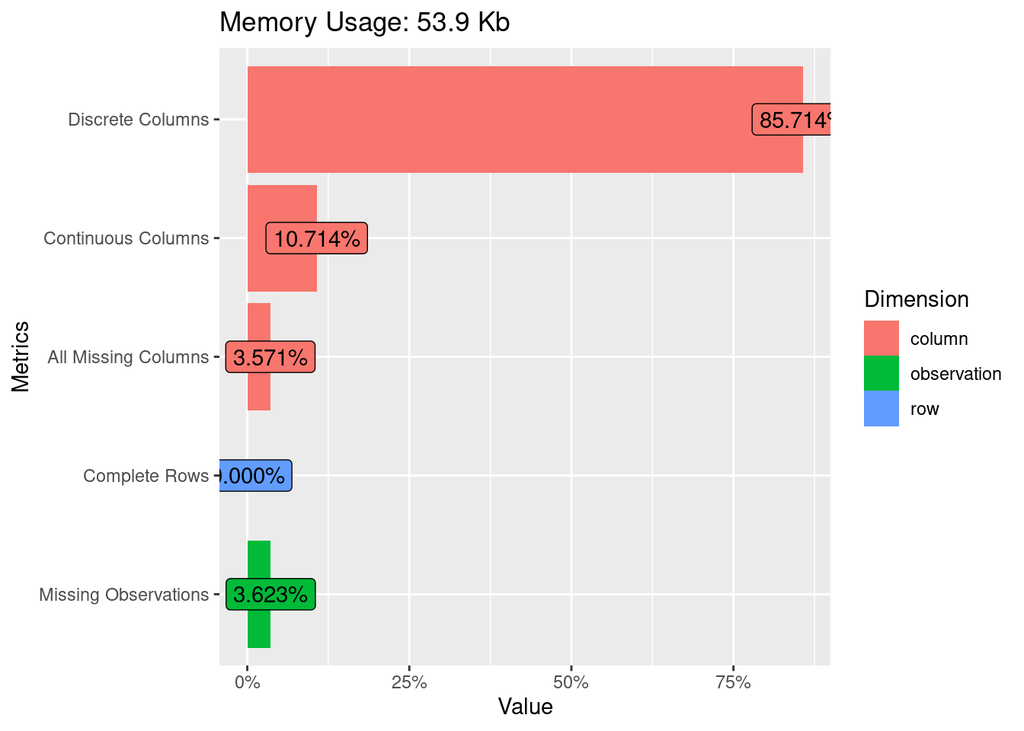

```r
plot_intro(demo_data)
```

### Gráfico de Barras

Cuenta con plots automáticos para generar multiples gráficos en un solo paso. La función `plot_bar()` permite generar gráficos de barras para cada variable del set de datos.

```
1 columns ignored with more than 50 categories.
amai_score: 76 categories
```

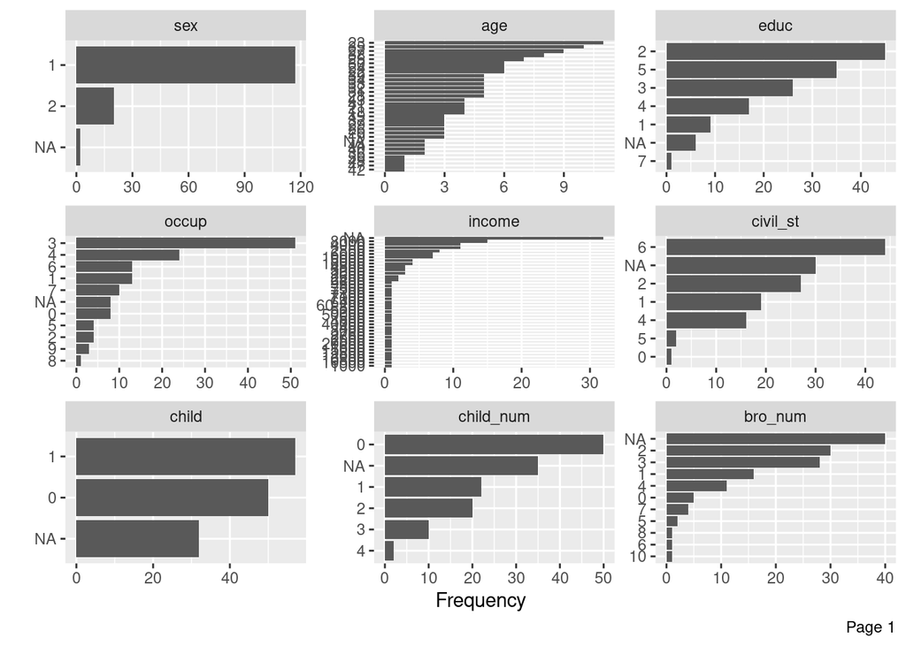

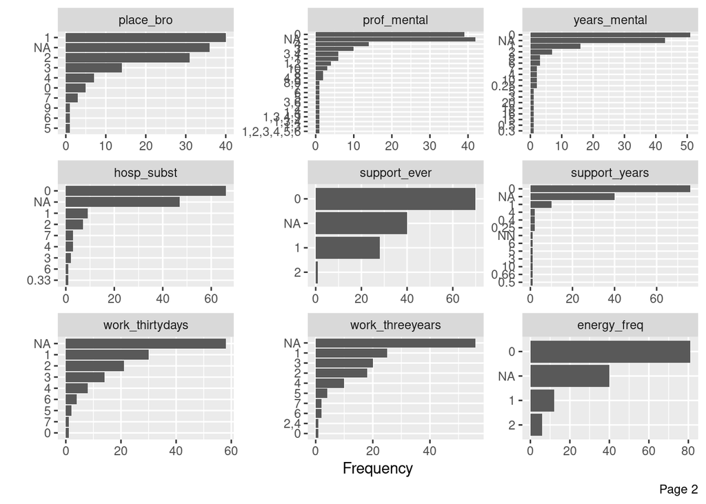

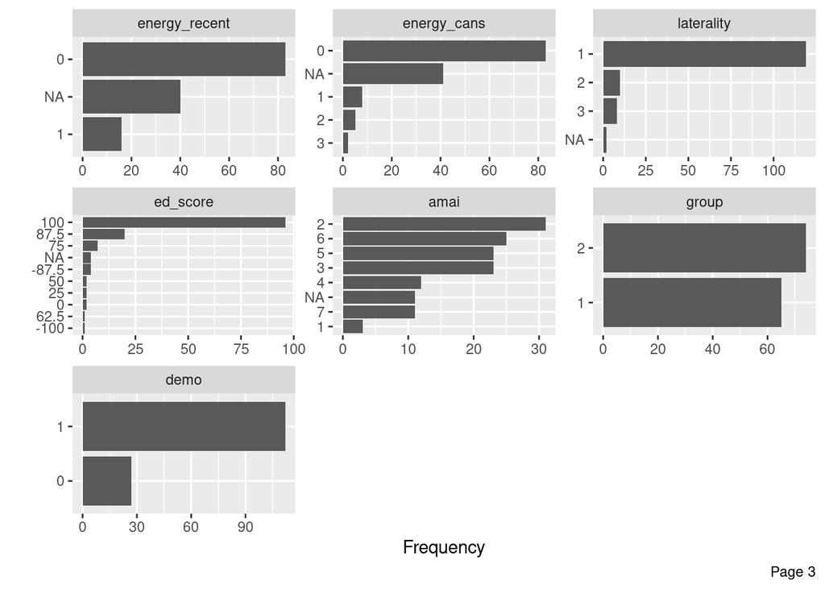

```r
plot_bar(demo_data)
```

### Correlación

Si bien R base permite ejecutar correlaciones de forma fácil y sin dependencias de otras librerías, esta implementación tiene un resultado bueno y su implementación es bastante simple.

**Warning**

Para obtener un buen resultado es importante procesar adecuadamente los registros faltantes así como codificar adecuadamente los tipos de variables.

```
17 features with more than 5 categories ignored!
age: 32 categories
educ: 7 categories
occup: 11 categories
income: 41 categories
civil_st: 7 categories
child_num: 6 categories
bro_num: 11 categories
place_bro: 10 categories
prof_mental: 22 categories
years_mental: 18 categories
hosp_subst: 10 categories
support_years: 13 categories
work_thirtydays: 9 categories
work_threeyears: 10 categories
ed_score: 10 categories
amai: 8 categories
amai_score: 76 categories
```

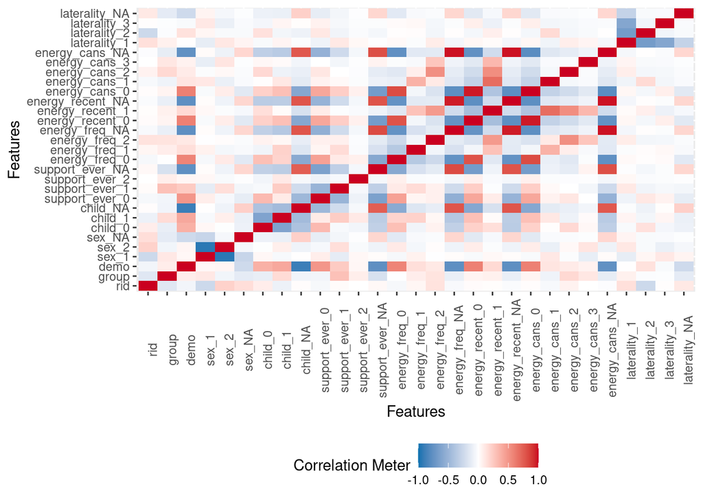

```r
plot_correlation(demo_data, maxcat=5L)
```

## summarytools

### descr

Esta librería también entrega descriptivos relacionados con los datos. Su funcionamiento es muy parecido a **Skimr** aunque la salida a nivel terminal no es tan buena como la de skim

```r
library(summarytools)

descr(demo_data)
```

```
Non-numerical variable(s) ignored: sex, age, educ, occup, income, civil_st, child, child_num, bro_num, place_bro, prof_mental, years_mental, hosp_subst, support_ever, support_years, work_thirtydays, work_threeyears, energy_freq, energy_recent, energy_cans, laterality, ed_score, amai, amai_score, not…
```

```
Descriptive Statistics
demo_data
N: 139

                      demo    group      rid
----------------- -------- -------- --------
             Mean     0.81     1.53    75.27
          Std.Dev     0.40     0.50    45.56
              Min     0.00     1.00     1.00
               Q1     1.00     1.00    35.00
           Median     1.00     2.00    73.00
               Q3     1.00     2.00   115.00
              Max     1.00     2.00   160.00
              MAD     0.00     0.00    57.82
              IQR     0.00     1.00    79.00
               CV     0.49     0.33     0.61
         Skewness    -1.53    -0.13     0.10
      SE.Skewness     0.21     0.21     0.21
         Kurtosis     0.34    -2.00    -1.23
          N.Valid   139.00   139.00   139.00
        Pct.Valid   100.00   100.00   100.00
```

### dfSummary

Sin embargo la salida de este paquete para **rmarkdowm**, **quarto** y **html** es mucho mas estética aunque requiere de comandos extra como `print()` con el método render para que se pueda ver directamente en la salida en `quatro()`.

La ejecución de `dfSummary()` sin los argumetos, por lo menos en Quarto escapa los caracteres y distorsiona el resultado

```r
print(dfSummary(
    demo_data,
    varnumbers = FALSE,
    valid.col = FALSE,
    graph.magnif = 0.76
),method = 'render')
```

Data Frame Summary

demo_data

**Dimensions**: 139 x 28  
**Duplicates**: 0

| **Variable** | **Stats / Values** | **Freqs (% of Valid)** | **Graph** | **Missing** |
| --- | --- | --- | --- | --- |
| rid [numeric] | Mean (sd) : 75.3 (45.6) min ≤ med ≤ max: 1 ≤ 73 ≤ 160 IQR (CV) : 79 (0.6) | 139 distinct values |  | 0 (0.0%) |
| group [numeric] | Min : 1 Mean : 1.5 Max : 2 | 1 : 65 ( 46.8% ) 2 : 74 ( 53.2% ) |  | 0 (0.0%) |
| demo [numeric] | Min : 0 Mean : 0.8 Max : 1 | 0 : 27 ( 19.4% ) 1 : 112 ( 80.6% ) |  | 0 (0.0%) |
| sex [character] | 1. 1 2. 2 3. NA | 117 ( 84.2% ) 20 ( 14.4% ) 2 ( 1.4% ) |  | 0 (0.0%) |
| age [character] | 1. 23 2. 35 3. 27 4. 38 5. 25 6. 22 7. 24 8. 30 9. 28 10. 31 [ 22 others ] | 11 ( 7.9% ) 10 ( 7.2% ) 9 ( 6.5% ) 8 ( 5.8% ) 7 ( 5.0% ) 6 ( 4.3% ) 6 ( 4.3% ) 6 ( 4.3% ) 5 ( 3.6% ) 5 ( 3.6% ) 66 ( 47.5% ) |  | 0 (0.0%) |
| educ [character] | 1. 1 2. 2 3. 3 4. 4 5. 5 6. 7 7. NA | 9 ( 6.5% ) 45 ( 32.4% ) 26 ( 18.7% ) 17 ( 12.2% ) 35 ( 25.2% ) 1 ( 0.7% ) 6 ( 4.3% ) |  | 0 (0.0%) |
| occup [character] | 1. 0 2. 1 3. 2 4. 3 5. 4 6. 5 7. 6 8. 7 9. 8 10. 9 11. NA | 8 ( 5.8% ) 13 ( 9.4% ) 4 ( 2.9% ) 51 ( 36.7% ) 24 ( 17.3% ) 4 ( 2.9% ) 13 ( 9.4% ) 10 ( 7.2% ) 1 ( 0.7% ) 3 ( 2.2% ) 8 ( 5.8% ) |  | 0 (0.0%) |
| income [character] | 1. NA 2. 8000 3. 0 4. 4000 5. 2800 6. 10000 7. 6000 8. 16000 9. 5000 10. 2000 [ 31 others ] | 32 ( 23.0% ) 15 ( 10.8% ) 11 ( 7.9% ) 11 ( 7.9% ) 8 ( 5.8% ) 7 ( 5.0% ) 7 ( 5.0% ) 4 ( 2.9% ) 4 ( 2.9% ) 3 ( 2.2% ) 37 ( 26.6% ) |  | 0 (0.0%) |
| civil_st [character] | 1. 0 2. 1 3. 2 4. 4 5. 5 6. 6 7. NA | 1 ( 0.7% ) 19 ( 13.7% ) 27 ( 19.4% ) 16 ( 11.5% ) 2 ( 1.4% ) 44 ( 31.7% ) 30 ( 21.6% ) |  | 0 (0.0%) |
| child [character] | 1. 0 2. 1 3. NA | 50 ( 36.0% ) 57 ( 41.0% ) 32 ( 23.0% ) |  | 0 (0.0%) |
| child_num [character] | 1. 0 2. 1 3. 2 4. 3 5. 4 6. NA | 50 ( 36.0% ) 22 ( 15.8% ) 20 ( 14.4% ) 10 ( 7.2% ) 2 ( 1.4% ) 35 ( 25.2% ) |  | 0 (0.0%) |
| bro_num [character] | 1. 0 2. 1 3. 10 4. 2 5. 3 6. 4 7. 5 8. 6 9. 7 10. 8 11. NA | 5 ( 3.6% ) 16 ( 11.5% ) 1 ( 0.7% ) 30 ( 21.6% ) 28 ( 20.1% ) 11 ( 7.9% ) 2 ( 1.4% ) 1 ( 0.7% ) 4 ( 2.9% ) 1 ( 0.7% ) 40 ( 28.8% ) |  | 0 (0.0%) |
| place_bro [character] | 1. 0 2. 1 3. 2 4. 3 5. 4 6. 5 7. 6 8. 7 9. 9 10. NA | 5 ( 3.6% ) 40 ( 28.8% ) 31 ( 22.3% ) 14 ( 10.1% ) 7 ( 5.0% ) 1 ( 0.7% ) 1 ( 0.7% ) 3 ( 2.2% ) 1 ( 0.7% ) 36 ( 25.9% ) |  | 0 (0.0%) |
| prof_mental [character] | 1. NA 2. 0 3. 4 4. 3 5. 1 6. 3,4 7. 1,2 8. 10 9. 4,8 10. 8 [ 11 others ] | 41 ( 29.7% ) 39 ( 28.3% ) 14 ( 10.1% ) 10 ( 7.2% ) 6 ( 4.3% ) 6 ( 4.3% ) 4 ( 2.9% ) 3 ( 2.2% ) 2 ( 1.4% ) 2 ( 1.4% ) 11 ( 8.0% ) |  | 1 (0.7%) |
| years_mental [character] | 1. 0 2. NA 3. 1 4. 2 5. 6 6. 8 7. 0.25 8. 10 9. 4 10. 7 [ 8 others ] | 51 ( 36.7% ) 43 ( 30.9% ) 16 ( 11.5% ) 7 ( 5.0% ) 3 ( 2.2% ) 3 ( 2.2% ) 2 ( 1.4% ) 2 ( 1.4% ) 2 ( 1.4% ) 2 ( 1.4% ) 8 ( 5.8% ) |  | 0 (0.0%) |
| hosp_subst [character] | 1. 0 2. 0.33 3. 1 4. 2 5. 3 6. 4 7. 6 8. 7 9. NA | 66 ( 47.8% ) 1 ( 0.7% ) 9 ( 6.5% ) 7 ( 5.1% ) 2 ( 1.4% ) 3 ( 2.2% ) 1 ( 0.7% ) 3 ( 2.2% ) 46 ( 33.3% ) |  | 1 (0.7%) |
| support_ever [character] | 1. 0 2. 1 3. 2 4. NA | 70 ( 50.4% ) 28 ( 20.1% ) 1 ( 0.7% ) 40 ( 28.8% ) |  | 0 (0.0%) |
| support_years [character] | 1. 0 2. NA 3. 1 4. 0.25 5. 0.4 6. 4 7. 0.5 8. 0.66 9. 10 10. 3 [ 3 others ] | 76 ( 54.7% ) 40 ( 28.8% ) 10 ( 7.2% ) 2 ( 1.4% ) 2 ( 1.4% ) 2 ( 1.4% ) 1 ( 0.7% ) 1 ( 0.7% ) 1 ( 0.7% ) 1 ( 0.7% ) 3 ( 2.2% ) |  | 0 (0.0%) |
| work_thirtydays [character] | 1. 0 2. 1 3. 2 4. 3 5. 4 6. 5 7. 6 8. 7 9. NA | 1 ( 0.7% ) 30 ( 21.6% ) 21 ( 15.1% ) 14 ( 10.1% ) 8 ( 5.8% ) 2 ( 1.4% ) 4 ( 2.9% ) 1 ( 0.7% ) 58 ( 41.7% ) |  | 0 (0.0%) |
| work_threeyears [character] | 1. 0 2. 1 3. 2 4. 2,4 5. 3 6. 4 7. 5 8. 6 9. 7 10. NA | 1 ( 0.7% ) 25 ( 18.0% ) 18 ( 12.9% ) 1 ( 0.7% ) 20 ( 14.4% ) 10 ( 7.2% ) 4 ( 2.9% ) 2 ( 1.4% ) 2 ( 1.4% ) 56 ( 40.3% ) |  | 0 (0.0%) |
| energy_freq [character] | 1. 0 2. 1 3. 2 4. NA | 81 ( 58.3% ) 12 ( 8.6% ) 6 ( 4.3% ) 40 ( 28.8% ) |  | 0 (0.0%) |
| energy_recent [character] | 1. 0 2. 1 3. NA | 83 ( 59.7% ) 16 ( 11.5% ) 40 ( 28.8% ) |  | 0 (0.0%) |
| energy_cans [character] | 1. 0 2. 1 3. 2 4. 3 5. NA | 83 ( 59.7% ) 8 ( 5.8% ) 5 ( 3.6% ) 2 ( 1.4% ) 41 ( 29.5% ) |  | 0 (0.0%) |
| laterality [character] | 1. 1 2. 2 3. 3 4. NA | 119 ( 85.6% ) 10 ( 7.2% ) 8 ( 5.8% ) 2 ( 1.4% ) |  | 0 (0.0%) |
| ed_score [character] | 1. -100 2. -87.5 3. 0 4. 100 5. 25 6. 50 7. 62.5 8. 75 9. 87.5 10. NA | 1 ( 0.7% ) 4 ( 2.9% ) 2 ( 1.4% ) 96 ( 69.1% ) 2 ( 1.4% ) 2 ( 1.4% ) 1 ( 0.7% ) 7 ( 5.0% ) 20 ( 14.4% ) 4 ( 2.9% ) |  | 0 (0.0%) |
| amai [character] | 1. 1 2. 2 3. 3 4. 4 5. 5 6. 6 7. 7 8. NA | 3 ( 2.2% ) 31 ( 22.3% ) 23 ( 16.5% ) 12 ( 8.6% ) 23 ( 16.5% ) 25 ( 18.0% ) 11 ( 7.9% ) 11 ( 7.9% ) |  | 0 (0.0%) |
| amai_score [character] | 1. NA 2. 84 3. 130 4. 176 5. 202 6. 83 7. 135 8. 169 9. 38 10. 58 [ 66 others ] | 11 ( 7.9% ) 6 ( 4.3% ) 4 ( 2.9% ) 4 ( 2.9% ) 4 ( 2.9% ) 4 ( 2.9% ) 3 ( 2.2% ) 3 ( 2.2% ) 3 ( 2.2% ) 3 ( 2.2% ) 94 ( 67.6% ) |  | 0 (0.0%) |
| notes [logical] | All NA's |  |  | 139 (100.0%) |

Generated by summarytools 1.0.1 ([R](https://www.r-project.org/) version 4.2.1)  
2022-10-08

## Notas Finales

Existen más paquetes que permiten realizar una exploración detalla y rápida de los datos, sin embargo un factor importante a considerar es la dependencia en otras librerías. Una recomendación es no incluir este tipo de análisis en el resultado final y solo usarlo de manera introductoria a los datos.

### Sobre Quarto

Este ejercicio también tiene como finalidad la exploración de **quarto** considerando:

- La integración de estos paquetes
- La comparación de el render en **quarto** con el render de Rmarkdown
- El uso de Visual Code como editor alternativo a Rstudio
- Y como referencia al uso de quarto con otros lenguajes como python.

Como una evaluación rápida que será ampliada con las subsequentes pruebas, Quarto es una herramienta muy parecida a Rmarkdown y la migración a este sistema puede ser transparente. Enlisto pros y contras de este sistema/setup:

#### Pros:

- Las opciones de configuración para el resultado son mas que las presentes en Rmarkdown
- Ademas estas características son faciles de configurar en el encabezado yaml y dentro de los chunks de código mediante el simbolo `#|`
- Incluye características dentro del paquete que previamente requerían de paquetes extra y configuraciones complejas
- Generar documentos no requiere de Rstudio para visualizar y obtener el resultado
- Concentra la creación de presentaciones con varias librerías de javascript cuyo uso es transparente par el usuario.
- Quarto en Rstudio funciona de igual forma que un RNotebook/ Rmarkdown.

Con la simple definición un tema claro y uno oscuro el render html presenta un botón para cambiar entre ambos

#### Contras:

- Requiere la instalación del paquete a nivel de sistema.
- Su uso en sistemas externos a Rstudio (VScode) requiere de plugins y/o un proceso ejecutandose en segundo plano para ver las modificaciones en timpo real
- De la mano con el punto anterior, los chunks de código no se ejecutan dentro del mismo documento como es el caso de Rmarkdown con Rstudio o de JupyterNotebook. Incluso con el plug in requiere de una terminal externa.

Rmarkdown tambien requiere instalaciones pero estas pueden obtenerse al instalar el paquete